# hw4pr1

## Welcome to cs35's *"Data-and-Modeling"* module...

**Installing and trying numpy, pandas, scipy, matplotlib, and seaborn**

- Installing seaborn and pandas will pull in numpy and matplotlib, so you'll have all four.
- So, the smoothest approach is to uncomment the two cells below and run them, e.g.,
- `!pip install pandas`
- The `-U` will upgrade, if you already have it. Also, your version may be named `pip3` (mine was)

```python
!pip3 install pandas    #  (This worked for me - if it doesn't for you, ask! :)
```

```python
!pip3 install seaborn   #  similar
```

```python
!pip3 install scikit-learn     # also similar
```

**Details about paths and installing libraries** - you may not need these...

- The key is to use the `pip` or `pip3` that corresponds to the Python that you use as a notebook kernel...
- For me, on a Mac desktop, it's `/usr/bin/local/pip3`
- For me, on a Win laptop, it's `c:\Users\dodds\AppData\Local\Progams\Python\Python311\Scripts\pip`
- Your path will vary!
- Clicking on your "chosen kernel" (at a notebook's upper right) and/or running these commands can help you find those paths:
  - `where python`
  - `where python3`
  - `where pip`
  - `where pip3`
- Most of all, do *ask* if you're running into trouble...

```python
# Let's start by exploring library-imports in general
# Note that notebooks are happy to interoperate with plain Python files...

# Here are the contents of morefun.py:
"""
#
# morefun.py
#

def f():
    return 'returned from f'

def fac():
    return 'returned from fac'
"""

# # ordinary library import
# import morefun
# print( f"{morefun.f() = }" )

# # renaming library import
# import morefun as mandatoryfun
# print( f"{mandatoryfun.fac() = }" )

# # single-function import
# from morefun import fac
# print( f"{fac() = }" )

# # single-function renaming import
# from morefun import fac as funfac   # as f
# print( f"{funfac() = }" )

# # all-functions import
# from morefun import *
# print( f"{f() = }" )          # truly an f string...

# # if a library needs to be reloaded:   # *** if you develop in more than one file, this can be very important! ***
# import importlib
# importlib.reload(morefun)
```

```
"\n#\n# morefun.py \n#\n\ndef f():\n    return 'returned from f'\n\ndef fac():\n    return 'returned from fac'\n"
```

```python
# Numpy is a Python library supporting fast, memory-efficient arrays of data
# Let's try it!

# this is numpy's traditional renaming import
import numpy as np
```

```python
#
# Our starting numpy examples:

print( f"{ np.arange(1,3,.1) = }\n" )
print( f"{ np.linspace(1,3,42) = }\n" )
print( f"{ np.ones( shape=(4,2) ) = }\n" )
print( f"{ np.zeros( (3, 4) ) = }\n" )
```

```
 np.arange(1,3,.1) = array([1. , 1.1, 1.2, 1.3, 1.4, 1.5, 1.6, 1.7, 1.8, 1.9, 2. , 2.1, 2.2,
       2.3, 2.4, 2.5, 2.6, 2.7, 2.8, 2.9])

 np.linspace(1,3,42) = array([1.        , 1.04878049, 1.09756098, 1.14634146, 1.19512195,
       1.24390244, 1.29268293, 1.34146341, 1.3902439 , 1.43902439,
       1.48780488, 1.53658537, 1.58536585, 1.63414634, 1.68292683,
       1.73170732, 1.7804878 , 1.82926829, 1.87804878, 1.92682927,
       1.97560976, 2.02439024, 2.07317073, 2.12195122, 2.17073171,
       2.2195122 , 2.26829268, 2.31707317, 2.36585366, 2.41463415,
       2.46341463, 2.51219512, 2.56097561, 2.6097561 , 2.65853659,
       2.70731707, 2.75609756, 2.80487805, 2.85365854, 2.90243902,
       2.95121951, 3.        ])

 np.ones( shape=(4,2) ) = array([[1., 1.],
       [1., 1.],
       [1., 1.],
       [1., 1.]])

 np.zeros( (3, 4) ) = array([[0., 0., 0., 0.],
       [0., 0., 0., 0.],
       [0., 0., 0., 0.]])
```

```python
# import three random-number-generation functions that create numpy arrays...
from numpy.random import rand, randn, randint

#
# Here, we show how to convert numpy arrays to/from Python lists (and lists-of-lists, etc.)
#
R = rand(2,4)                 # uniform from 0 to 1
print(f"{R = }\n" )

Rn = randn(2,4)               # normally (bell-curve) distributed, mean 0, stdev. 1
print(f"{Rn = }\n" )

A = randint(0,10,size=(2,4))  # let's use one-digit values for ease of printing
print(f"A is\n{A}\n")

L = A.tolist()                # this converts to a Python structure!
print(f"L is\n{L}\n")

A = np.asarray(L)             # and back to a numpy array...
print(f"A is\n{A}\n")

# Notice the slight differences in printing: Python uses commas, Numpy does not
```

```
R = array([[0.4094317 , 0.50811382, 0.06908669, 0.28189155],
       [0.18991347, 0.88827027, 0.31202854, 0.22107814]])

Rn = array([[ 1.5181411 ,  0.70418218,  1.58868597, -0.65756156],
       [-1.16270431, -0.24264117,  0.78934739, -1.1041575 ]])

A is
[[8 4 8 5]
 [0 0 0 3]]

L is
[[8, 4, 8, 5], [0, 0, 0, 3]]

A is
[[8 4 8 5]
 [0 0 0 3]]
```

```python
print(f"{A = }\n")
A
```

```
A = array([[8, 4, 8, 5],
       [0, 0, 0, 3]])
```

```
array([[8, 4, 8, 5],
       [0, 0, 0, 3]])
```

```python
# in-class "screenshot challenge" example

# Python functions (range) and list comprehensions are still available...

L = [ list(range(low,low+6)) for low in range(0,60,10) ]     # low runs over [0,10,20,30,40,50]

A = np.asarray(L)        # convert to a numpy Array

print(f"A.shape is {A.shape}\n")   # (nrows, ncols)    symmetry hiding the difference here...

print(f"A is\n{A}\n")
A
```

```
A.shape is (6, 6)

A is
[[ 0  1  2  3  4  5]
 [10 11 12 13 14 15]
 [20 21 22 23 24 25]
 [30 31 32 33 34 35]
 [40 41 42 43 44 45]
 [50 51 52 53 54 55]]
```

```
array([[ 0,  1,  2,  3,  4,  5],
       [10, 11, 12, 13, 14, 15],
       [20, 21, 22, 23, 24, 25],
       [30, 31, 32, 33, 34, 35],
       [40, 41, 42, 43, 44, 45],
       [50, 51, 52, 53, 54, 55]])
```

```python
A[1:3,0:2]   # showing off 2-dimensional slicing!
```

```
array([[10, 11],
       [20, 21]])
```

```python
L = [5,6,7,8,9]
print("Slice is", L[0:2])  # [0:200]
```

```
Slice is [5, 6]
```

## Part (a): House Hunters!

Welcome to the wonderful world of real estate! This introduction to pandas brought to you by Kanalu Monaco '24. Kanalu:

Buying a home is a huge life decision, and it is important to be informed about the housing market. We will analyze some housing data using Pandas!

What does pandas stand for?

- Python Data Analysis Library?
- Panel Data?
- *Who knows!?* (it's actually both)

Big-picture, Pandas uses a spreadsheet-like object called a "DataFrame" to store information. We will see how convenient this data frame is!

#### Pandas and our housing dataset

```python
# Let's continue by importing the pandas library
import pandas as pd   # abbreviated "pd"
```

We have a housing csv (reminder: "comma-separated values") file with all the data we want to analyze (Thank you, Internet!)

Pandas has a function that makes it easy to import data: read_csv

read_csv can take a whole bunch of different inputs, but for now, we can just pass in the name of the file we want to open as a string. If the file is not in the same folder as your notebook file, you can pass in a path from the notebook directory to the file directory (as a string).

This function will automatically convert the data in the csv file into the data frame that pandas uses. Be sure to give the data frame a name for easy reference later!

```python
# We will import the data as a dataframe called "zillow"
zillow = pd.read_csv('./housing.csv')
```

You can type 'zillow' to view the data frame.

By default, it will only display the first and last 5 rows of the data frame.

Alternatively, you can use `zillow.head(n)` to view the first `n` (n<=60) rows only, or `zillow.tail(n)` to view the last `n` rows.

If you *really* want to see every row... a loop is your best bet! (It's rare to need this - and better in csv form!!)

```python
# Let's see what our dataframe looks like
zillow
```

|  | Order | PID | MS SubClass | MS Zoning | Lot Frontage | Lot Area | Street | Alley | Lot Shape | Land Contour | ... | Pool QC | Fence | Misc Feature | Misc Val | Mo Sold | Yr Sold | Sale Type | Sale Condition | SalePrice | how many datasets have journal papers? This one does! http://jse.amstat.org/v19n3/decock.pdf |
| --- | --- | --- | --- | --- | --- | --- | --- | --- | --- | --- | --- | --- | --- | --- | --- | --- | --- | --- | --- | --- | --- |
| 0 | 1 | 526301100 | 20 | RL | 141.0 | 31770 | Pave | NaN | IR1 | Lvl | ... | NaN | NaN | NaN | 0 | 5 | 2010 | WD | Normal | 215000 | NaN |
| 1 | 2 | 526350040 | 20 | RH | 80.0 | 11622 | Pave | NaN | Reg | Lvl | ... | NaN | MnPrv | NaN | 0 | 6 | 2010 | WD | Normal | 105000 | NaN |
| 2 | 3 | 526351010 | 20 | RL | 81.0 | 14267 | Pave | NaN | IR1 | Lvl | ... | NaN | NaN | Gar2 | 12500 | 6 | 2010 | WD | Normal | 172000 | NaN |
| 3 | 4 | 526353030 | 20 | RL | 93.0 | 11160 | Pave | NaN | Reg | Lvl | ... | NaN | NaN | NaN | 0 | 4 | 2010 | WD | Normal | 244000 | NaN |
| 4 | 5 | 527105010 | 60 | RL | 74.0 | 13830 | Pave | NaN | IR1 | Lvl | ... | NaN | MnPrv | NaN | 0 | 3 | 2010 | WD | Normal | 189900 | NaN |
| ... | ... | ... | ... | ... | ... | ... | ... | ... | ... | ... | ... | ... | ... | ... | ... | ... | ... | ... | ... | ... | ... |
| 2925 | 2926 | 923275080 | 80 | RL | 37.0 | 7937 | Pave | NaN | IR1 | Lvl | ... | NaN | GdPrv | NaN | 0 | 3 | 2006 | WD | Normal | 142500 | NaN |
| 2926 | 2927 | 923276100 | 20 | RL | NaN | 8885 | Pave | NaN | IR1 | Low | ... | NaN | MnPrv | NaN | 0 | 6 | 2006 | WD | Normal | 131000 | NaN |
| 2927 | 2928 | 923400125 | 85 | RL | 62.0 | 10441 | Pave | NaN | Reg | Lvl | ... | NaN | MnPrv | Shed | 700 | 7 | 2006 | WD | Normal | 132000 | NaN |
| 2928 | 2929 | 924100070 | 20 | RL | 77.0 | 10010 | Pave | NaN | Reg | Lvl | ... | NaN | NaN | NaN | 0 | 4 | 2006 | WD | Normal | 170000 | NaN |
| 2929 | 2930 | 924151050 | 60 | RL | 74.0 | 9627 | Pave | NaN | Reg | Lvl | ... | NaN | NaN | NaN | 0 | 11 | 2006 | WD | Normal | 188000 | NaN |

2930 rows × 83 columns

As you can see, pandas organizes the data in a friendly, familiar, spreadsheet-y way (and there's a lot of data to be organized!)

There are a lot of ways to view and access the data. We will go over some of the basic ones

```python
# We can view all of the columns available
zillow.columns
```

```
Index(['Order', 'PID', 'MS SubClass', 'MS Zoning', 'Lot Frontage', 'Lot Area',
       'Street', 'Alley', 'Lot Shape', 'Land Contour', 'Utilities',
       'Lot Config', 'Land Slope', 'Neighborhood', 'Condition 1',
       'Condition 2', 'Bldg Type', 'House Style', 'Overall Qual',
       'Overall Cond', 'Year Built', 'Year Remod/Add', 'Roof Style',
       'Roof Matl', 'Exterior 1st', 'Exterior 2nd', 'Mas Vnr Type',
       'Mas Vnr Area', 'Exter Qual', 'Exter Cond', 'Foundation', 'Bsmt Qual',
       'Bsmt Cond', 'Bsmt Exposure', 'BsmtFin Type 1', 'BsmtFin SF 1',
       'BsmtFin Type 2', 'BsmtFin SF 2', 'Bsmt Unf SF', 'Total Bsmt SF',
       'Heating', 'Heating QC', 'Central Air', 'Electrical', '1st Flr SF',
       '2nd Flr SF', 'Low Qual Fin SF', 'Gr Liv Area', 'Bsmt Full Bath',
       'Bsmt Half Bath', 'Full Bath', 'Half Bath', 'Bedroom AbvGr',
       'Kitchen AbvGr', 'Kitchen Qual', 'TotRms AbvGrd', 'Functional',
       'Fireplaces', 'Fireplace Qu', 'Garage Type', 'Garage Yr Blt',
       'Garage Finish', 'Garage Cars', 'Garage Area', 'Garage Qual',
       'Garage Cond', 'Paved Drive', 'Wood Deck SF', 'Open Porch SF',
       'Enclosed Porch', '3Ssn Porch', 'Screen Porch', 'Pool Area', 'Pool QC',
       'Fence', 'Misc Feature', 'Misc Val', 'Mo Sold', 'Yr Sold', 'Sale Type',
       'Sale Condition', 'SalePrice',
       'how many datasets have journal papers? This one does!  http://jse.amstat.org/v19n3/decock.pdf'],
      dtype='object')
```

#### References to explain all of these columns!

- The last column isn't real data, but a link to additional information. We'll drop it momentarily...
- This dataset is so large, however, that a reference to its columns may be needed.
- [This is a link to a plain-text file describing the columns in detail](https://jse.amstat.org/v19n3/decock/DataDocumentation.txt)
- [This is a link to a Kaggle exploration of this dataset](https://www.kaggle.com/leeclemmer/exploratory-data-analysis-of-housing-in-ames-iowa)
- For this walkthrough, you may not need these, but - they're here.

```python
# That last "column" is not really a column, let's drop it:
ROW = 0    # this is one of the constants for defining which axis is which
COLUMN=1   # this is another such constant
zillow2 = zillow.drop(zillow.columns[-1], axis=COLUMN)   # more readable than axis=1
zillow2
```

|  | Order | PID | MS SubClass | MS Zoning | Lot Frontage | Lot Area | Street | Alley | Lot Shape | Land Contour | ... | Pool Area | Pool QC | Fence | Misc Feature | Misc Val | Mo Sold | Yr Sold | Sale Type | Sale Condition | SalePrice |
| --- | --- | --- | --- | --- | --- | --- | --- | --- | --- | --- | --- | --- | --- | --- | --- | --- | --- | --- | --- | --- | --- |
| 0 | 1 | 526301100 | 20 | RL | 141.0 | 31770 | Pave | NaN | IR1 | Lvl | ... | 0 | NaN | NaN | NaN | 0 | 5 | 2010 | WD | Normal | 215000 |
| 1 | 2 | 526350040 | 20 | RH | 80.0 | 11622 | Pave | NaN | Reg | Lvl | ... | 0 | NaN | MnPrv | NaN | 0 | 6 | 2010 | WD | Normal | 105000 |
| 2 | 3 | 526351010 | 20 | RL | 81.0 | 14267 | Pave | NaN | IR1 | Lvl | ... | 0 | NaN | NaN | Gar2 | 12500 | 6 | 2010 | WD | Normal | 172000 |
| 3 | 4 | 526353030 | 20 | RL | 93.0 | 11160 | Pave | NaN | Reg | Lvl | ... | 0 | NaN | NaN | NaN | 0 | 4 | 2010 | WD | Normal | 244000 |
| 4 | 5 | 527105010 | 60 | RL | 74.0 | 13830 | Pave | NaN | IR1 | Lvl | ... | 0 | NaN | MnPrv | NaN | 0 | 3 | 2010 | WD | Normal | 189900 |
| ... | ... | ... | ... | ... | ... | ... | ... | ... | ... | ... | ... | ... | ... | ... | ... | ... | ... | ... | ... | ... | ... |
| 2925 | 2926 | 923275080 | 80 | RL | 37.0 | 7937 | Pave | NaN | IR1 | Lvl | ... | 0 | NaN | GdPrv | NaN | 0 | 3 | 2006 | WD | Normal | 142500 |
| 2926 | 2927 | 923276100 | 20 | RL | NaN | 8885 | Pave | NaN | IR1 | Low | ... | 0 | NaN | MnPrv | NaN | 0 | 6 | 2006 | WD | Normal | 131000 |
| 2927 | 2928 | 923400125 | 85 | RL | 62.0 | 10441 | Pave | NaN | Reg | Lvl | ... | 0 | NaN | MnPrv | Shed | 700 | 7 | 2006 | WD | Normal | 132000 |
| 2928 | 2929 | 924100070 | 20 | RL | 77.0 | 10010 | Pave | NaN | Reg | Lvl | ... | 0 | NaN | NaN | NaN | 0 | 4 | 2006 | WD | Normal | 170000 |
| 2929 | 2930 | 924151050 | 60 | RL | 74.0 | 9627 | Pave | NaN | Reg | Lvl | ... | 0 | NaN | NaN | NaN | 0 | 11 | 2006 | WD | Normal | 188000 |

2930 rows × 82 columns

```python
zillow2.columns
```

```
Index(['Order', 'PID', 'MS SubClass', 'MS Zoning', 'Lot Frontage', 'Lot Area',
       'Street', 'Alley', 'Lot Shape', 'Land Contour', 'Utilities',
       'Lot Config', 'Land Slope', 'Neighborhood', 'Condition 1',
       'Condition 2', 'Bldg Type', 'House Style', 'Overall Qual',
       'Overall Cond', 'Year Built', 'Year Remod/Add', 'Roof Style',
       'Roof Matl', 'Exterior 1st', 'Exterior 2nd', 'Mas Vnr Type',
       'Mas Vnr Area', 'Exter Qual', 'Exter Cond', 'Foundation', 'Bsmt Qual',
       'Bsmt Cond', 'Bsmt Exposure', 'BsmtFin Type 1', 'BsmtFin SF 1',
       'BsmtFin Type 2', 'BsmtFin SF 2', 'Bsmt Unf SF', 'Total Bsmt SF',
       'Heating', 'Heating QC', 'Central Air', 'Electrical', '1st Flr SF',
       '2nd Flr SF', 'Low Qual Fin SF', 'Gr Liv Area', 'Bsmt Full Bath',
       'Bsmt Half Bath', 'Full Bath', 'Half Bath', 'Bedroom AbvGr',
       'Kitchen AbvGr', 'Kitchen Qual', 'TotRms AbvGrd', 'Functional',
       'Fireplaces', 'Fireplace Qu', 'Garage Type', 'Garage Yr Blt',
       'Garage Finish', 'Garage Cars', 'Garage Area', 'Garage Qual',
       'Garage Cond', 'Paved Drive', 'Wood Deck SF', 'Open Porch SF',
       'Enclosed Porch', '3Ssn Porch', 'Screen Porch', 'Pool Area', 'Pool QC',
       'Fence', 'Misc Feature', 'Misc Val', 'Mo Sold', 'Yr Sold', 'Sale Type',
       'Sale Condition', 'SalePrice'],
      dtype='object')
```

```python
# Let's rename zillow
zillow = zillow2     # this is without that url-column
```

```python
# We can access a column by inputting its name in brackets like so (a single column is, officially, a "Series")
zillow['SalePrice']
```

```
0       215000
1       105000
2       172000
3       244000
4       189900
         ...
2925    142500
2926    131000
2927    132000
2928    170000
2929    188000
Name: SalePrice, Length: 2930, dtype: int64
```

```python
# We can access a single value by using its index
zillow['SalePrice'][2]
```

```
172000
```

```python
# We even slice the column, as with a Python list...
zillow['SalePrice'][0:3]
```

```
0    215000
1    105000
2    172000
Name: SalePrice, dtype: int64
```

```python
# We can use zillow.loc[n] to locate a house (one row) by its index number n (0-2929)
zillow.loc[0]
```

```
Order                     1
PID               526301100
MS SubClass              20
MS Zoning                RL
Lot Frontage          141.0
                    ...
Mo Sold                   5
Yr Sold                2010
Sale Type                WD
Sale Condition       Normal
SalePrice            215000
Name: 0, Length: 82, dtype: object
```

```python
# a common pandas pattern is to create a series of Trues and Falses
zillow['SalePrice'] == 172000

# note that this applies the conditional to each of the elements of the the series, zillow['SalePrice']
```

```
0       False
1       False
2        True
3       False
4       False
        ...
2925    False
2926    False
2927    False
2928    False
2929    False
Name: SalePrice, Length: 2930, dtype: bool
```

```python
# this series of booleans can be used to "subset" a data frame

# This command locates all of the houses whose sale prices are $172000
zillow.loc[ zillow['SalePrice'] == 172000 ]
```

|  | Order | PID | MS SubClass | MS Zoning | Lot Frontage | Lot Area | Street | Alley | Lot Shape | Land Contour | ... | Pool Area | Pool QC | Fence | Misc Feature | Misc Val | Mo Sold | Yr Sold | Sale Type | Sale Condition | SalePrice |
| --- | --- | --- | --- | --- | --- | --- | --- | --- | --- | --- | --- | --- | --- | --- | --- | --- | --- | --- | --- | --- | --- |
| 2 | 3 | 526351010 | 20 | RL | 81.0 | 14267 | Pave | NaN | IR1 | Lvl | ... | 0 | NaN | NaN | Gar2 | 12500 | 6 | 2010 | WD | Normal | 172000 |
| 1609 | 1610 | 924100020 | 60 | RL | NaN | 11075 | Pave | NaN | IR1 | Lvl | ... | 0 | NaN | MnPrv | Shed | 400 | 9 | 2008 | WD | Normal | 172000 |
| 1952 | 1953 | 535402140 | 80 | RL | 93.0 | 10090 | Pave | NaN | IR1 | Lvl | ... | 0 | NaN | MnPrv | NaN | 0 | 10 | 2007 | WD | Normal | 172000 |
| 2352 | 2353 | 527358090 | 85 | RL | NaN | 9927 | Pave | NaN | IR1 | Lvl | ... | 0 | NaN | NaN | NaN | 0 | 7 | 2006 | WD | Normal | 172000 |
| 2480 | 2481 | 531452080 | 120 | RL | 50.0 | 7175 | Pave | NaN | Reg | Lvl | ... | 0 | NaN | MnPrv | NaN | 0 | 7 | 2006 | WD | Normal | 172000 |
| 2566 | 2567 | 535103070 | 80 | RL | NaN | 12700 | Pave | NaN | IR1 | Lvl | ... | 0 | NaN | NaN | NaN | 0 | 11 | 2006 | WD | Normal | 172000 |

6 rows × 82 columns

```python
#
# This gives us access to a much smaller subset...
houses_for_172k = zillow.loc[ zillow['SalePrice'] == 172000 ]
print(f"The len of houses_for_172k is {len(houses_for_172k)}")
```

```
The len of houses_for_172k is 6
```

```python
# other boolean conditions are also welcome...

# This command locates all of the houses whose sale prices are < $172000
houses_under_172k = zillow.loc[ zillow['SalePrice'] < 172000 ]
print(f"The len of houses_under_172k is {len(houses_under_172k)}")
```

```
The len of houses_under_172k is 1636
```

```python
# By default, loc[] extracts all columns of information
# We can pass specific columns we want to view (as a list if there are more than 1)

target_info = zillow.loc[zillow['SalePrice'] == 172000, ['SalePrice','Central Air', 'Full Bath']]
target_info
```

|  | SalePrice | Central Air | Full Bath |
| --- | --- | --- | --- |
| 2 | 172000 | Y | 1 |
| 1609 | 172000 | Y | 2 |
| 1952 | 172000 | Y | 2 |
| 2352 | 172000 | Y | 1 |
| 2480 | 172000 | Y | 2 |
| 2566 | 172000 | Y | 1 |

When accessing data in a data frame, it is usually necessary to know the index of the data you want!

Sometimes default indices are not useful. As an example, we will re-index our data frame so that we can search for homes by order number!

- Note that Order number -- the column named 'Order' -- is simply 1 more than the default index
- So, this is not a huge change
- However, it means that, if you're a fan of 1-indexed data -- that choice is up to you!
- Admission: Myself, I'm too used to and partial to 0-indexed data to change, generally speaking...

```python
# let's see the series of data that is zillow's 'Order' column:
zillow['Order']
```

```
0          1
1          2
2          3
3          4
4          5
        ...
2925    2926
2926    2927
2927    2928
2928    2929
2929    2930
Name: Order, Length: 2930, dtype: int64
```

```python
# We can use zillow.set_index(column) to set a given column as our indices insetad of 0-2929!
# Setting the 'inplace' parameter as True causes the existing data frame to change when we call set_index (insetad of creating a new data frame)
# Setting the 'drop' parameter as False keeps the original column in the data frame (instead of deleting it)
zillow_one = zillow.set_index('Order', drop=False)   # inplace = True  (if we want to replace the original)
zillow_one
```

| Order | Order | PID | MS SubClass | MS Zoning | Lot Frontage | Lot Area | Street | Alley | Lot Shape | Land Contour | ... | Pool Area | Pool QC | Fence | Misc Feature | Misc Val | Mo Sold | Yr Sold | Sale Type | Sale Condition | SalePrice |
| --- | --- | --- | --- | --- | --- | --- | --- | --- | --- | --- | --- | --- | --- | --- | --- | --- | --- | --- | --- | --- | --- |
| 1 | 1 | 526301100 | 20 | RL | 141.0 | 31770 | Pave | NaN | IR1 | Lvl | ... | 0 | NaN | NaN | NaN | 0 | 5 | 2010 | WD | Normal | 215000 |
| 2 | 2 | 526350040 | 20 | RH | 80.0 | 11622 | Pave | NaN | Reg | Lvl | ... | 0 | NaN | MnPrv | NaN | 0 | 6 | 2010 | WD | Normal | 105000 |
| 3 | 3 | 526351010 | 20 | RL | 81.0 | 14267 | Pave | NaN | IR1 | Lvl | ... | 0 | NaN | NaN | Gar2 | 12500 | 6 | 2010 | WD | Normal | 172000 |
| 4 | 4 | 526353030 | 20 | RL | 93.0 | 11160 | Pave | NaN | Reg | Lvl | ... | 0 | NaN | NaN | NaN | 0 | 4 | 2010 | WD | Normal | 244000 |
| 5 | 5 | 527105010 | 60 | RL | 74.0 | 13830 | Pave | NaN | IR1 | Lvl | ... | 0 | NaN | MnPrv | NaN | 0 | 3 | 2010 | WD | Normal | 189900 |
| ... | ... | ... | ... | ... | ... | ... | ... | ... | ... | ... | ... | ... | ... | ... | ... | ... | ... | ... | ... | ... | ... |
| 2926 | 2926 | 923275080 | 80 | RL | 37.0 | 7937 | Pave | NaN | IR1 | Lvl | ... | 0 | NaN | GdPrv | NaN | 0 | 3 | 2006 | WD | Normal | 142500 |
| 2927 | 2927 | 923276100 | 20 | RL | NaN | 8885 | Pave | NaN | IR1 | Low | ... | 0 | NaN | MnPrv | NaN | 0 | 6 | 2006 | WD | Normal | 131000 |
| 2928 | 2928 | 923400125 | 85 | RL | 62.0 | 10441 | Pave | NaN | Reg | Lvl | ... | 0 | NaN | MnPrv | Shed | 700 | 7 | 2006 | WD | Normal | 132000 |
| 2929 | 2929 | 924100070 | 20 | RL | 77.0 | 10010 | Pave | NaN | Reg | Lvl | ... | 0 | NaN | NaN | NaN | 0 | 4 | 2006 | WD | Normal | 170000 |
| 2930 | 2930 | 924151050 | 60 | RL | 74.0 | 9627 | Pave | NaN | Reg | Lvl | ... | 0 | NaN | NaN | NaN | 0 | 11 | 2006 | WD | Normal | 188000 |

2930 rows × 82 columns

```python
# Now we can use loc[] to find search for homes by order number
zillow_one.loc[2930]

# And you can make the index whatever you want!
```

```
Order                  2930
PID               924151050
MS SubClass              60
MS Zoning                RL
Lot Frontage           74.0
                    ...
Mo Sold                  11
Yr Sold                2006
Sale Type                WD
Sale Condition       Normal
SalePrice            188000
Name: 2930, Length: 82, dtype: object
```

**hw4pr1 (example/task0):**

We can "chain" a set of dataframes to find the order number of this house... and all of the data in its row.

- Below is that result, it's Order #2351 (index #2350)

Model your solution to task #1 (next cell) on this!

```python
z1 = zillow.loc[zillow['Screen Porch']>100]
z2 = z1.loc[z1['Pool Area']>100]
z3 = z2.loc[z2['Lot Area']>14200]
z3

#Pool Area (Continuous): Pool area in square feet
```

|  | Order | PID | MS SubClass | MS Zoning | Lot Frontage | Lot Area | Street | Alley | Lot Shape | Land Contour | ... | Pool Area | Pool QC | Fence | Misc Feature | Misc Val | Mo Sold | Yr Sold | Sale Type | Sale Condition | SalePrice |
| --- | --- | --- | --- | --- | --- | --- | --- | --- | --- | --- | --- | --- | --- | --- | --- | --- | --- | --- | --- | --- | --- |
| 2350 | 2351 | 527356020 | 60 | RL | 80.0 | 16692 | Pave | NaN | IR1 | Lvl | ... | 519 | Fa | MnPrv | TenC | 2000 | 7 | 2006 | WD | Normal | 250000 |

1 rows × 82 columns

### hw4pr1, task #1

You are working at a real estate company as an underpaid intern. Your boss asks you to find the order number of a house that they sold several years ago. They give you the following information:

- The SalePrice was less than $300000
- The Yr Sold is 2010
- The Lot Area is greater than 10000
- The number of "above ground" bedrooms (Bedroom AbvGr) is 3
- The Month Sold was June (June == 6)
- The overall quality score was 9 (out of 10)

Find the order number of this house! (and all of the data in its row)

- HINT: Start by creating a NEW data frame that applies just one of the filters, and continue from there...
- ALSO: You'll know you have the correct result when you see it...

```python
# here is a cell to work on hw4pr1 task #1
z1 = zillow.loc[zillow['SalePrice']<300000]
z2 = z1.loc[z1['Yr Sold']==2010]
z3 = z2.loc[z2['Lot Area']>10000]
z4 = z3.loc[z3['Bedroom AbvGr']==3]
z5 = z4.loc[z4['Mo Sold']==6]
z6 = z5.loc[z5['Overall Qual']==9]
z6
```

|  | Order | PID | MS SubClass | MS Zoning | Lot Frontage | Lot Area | Street | Alley | Lot Shape | Land Contour | ... | Pool Area | Pool QC | Fence | Misc Feature | Misc Val | Mo Sold | Yr Sold | Sale Type | Sale Condition | SalePrice |
| --- | --- | --- | --- | --- | --- | --- | --- | --- | --- | --- | --- | --- | --- | --- | --- | --- | --- | --- | --- | --- | --- |
| 41 | 42 | 528120120 | 20 | RL | 90.0 | 11520 | Pave | NaN | Reg | Lvl | ... | 0 | NaN | NaN | NaN | 0 | 6 | 2010 | WD | Normal | 275000 |

1 rows × 82 columns

## Part (b): Sea-ing the Data with *Seaborn*

There are many great tools like Pandas and Numpy that allow you to easily manipulate data. But what's often more important is VISUALIZING the data.

Matplotlib provides a great way to create graphs from data, but the syntax is often very cumbersome.

Seaborn is essentially a "high-level" library that uses matplotlib to make graphs with less required code!

Where does the name "Seaborn" come from? We are open to suggestions...

```python
# We will need data in order to make graphs! We will use pandas
import pandas as pd

# matplotlib is an essential whenever we are making graphs!
# Seaborn is simply a shortcut for using matplotlib!
import matplotlib.pyplot as plt

# Import Seaborn!
import seaborn as sns
```

```python
# Next, we import import our dataframe using pandas
iris_orig = pd.read_csv('./iris.csv')
iris_orig
```

|  | sepallen | sepalwid | petallen | petalwid | irisname | adapted from https://en.wikipedia.org/wiki/Iris_flower_data_set |
| --- | --- | --- | --- | --- | --- | --- |
| 0 | 4.6 | 3.60 | 1.0 | 0.200 | setosa | NaN |
| 1 | 4.3 | 3.00 | 1.1 | 0.100 | setosa | NaN |
| 2 | 5.0 | 3.20 | 1.2 | 0.200 | setosa | NaN |
| 3 | 5.8 | 4.00 | 1.2 | 0.200 | setosa | NaN |
| 4 | 4.4 | 3.00 | 1.3 | 0.200 | setosa | NaN |
| ... | ... | ... | ... | ... | ... | ... |
| 138 | 7.7 | 3.80 | 6.7 | 2.200 | virginica | NaN |
| 139 | 7.7 | 2.80 | 6.7 | 2.000 | virginica | NaN |
| 140 | 7.7 | 2.60 | 6.9 | 2.300 | virginica | NaN |
| 141 | 4.2 | 4.70 | 4.7 | 0.042 | alieniris | NaN |
| 142 | 4.2 | 4.77 | 4.7 | 0.047 | alieniris | NaN |

143 rows × 6 columns

```python
# we can drop a series of data (a row or a column)
# they're indicated by numeric value, row~0, col~1, but let's use readable names instead:
ROW = 0
COLUMN = 1

iris2 = iris_orig.drop('adapted from https://en.wikipedia.org/wiki/Iris_flower_data_set', axis=COLUMN)
iris2

# iris2 is a new dataframe, without that unwanted column,
# which had really just been a single element taking up a whole column...
```

|  | sepallen | sepalwid | petallen | petalwid | irisname |
| --- | --- | --- | --- | --- | --- |
| 0 | 4.6 | 3.60 | 1.0 | 0.200 | setosa |
| 1 | 4.3 | 3.00 | 1.1 | 0.100 | setosa |
| 2 | 5.0 | 3.20 | 1.2 | 0.200 | setosa |
| 3 | 5.8 | 4.00 | 1.2 | 0.200 | setosa |
| 4 | 4.4 | 3.00 | 1.3 | 0.200 | setosa |
| ... | ... | ... | ... | ... | ... |
| 138 | 7.7 | 3.80 | 6.7 | 2.200 | virginica |
| 139 | 7.7 | 2.80 | 6.7 | 2.000 | virginica |
| 140 | 7.7 | 2.60 | 6.9 | 2.300 | virginica |
| 141 | 4.2 | 4.70 | 4.7 | 0.042 | alieniris |
| 142 | 4.2 | 4.77 | 4.7 | 0.047 | alieniris |

143 rows × 5 columns

```python
# Those last two rows look suspicious...
iris3 = iris2.drop(142, axis=ROW)
iris4 = iris3.drop(141, axis=ROW)
iris = iris4
iris                 # our final dataframe-name
```

|  | sepallen | sepalwid | petallen | petalwid | irisname |
| --- | --- | --- | --- | --- | --- |
| 0 | 4.6 | 3.6 | 1.0 | 0.2 | setosa |
| 1 | 4.3 | 3.0 | 1.1 | 0.1 | setosa |
| 2 | 5.0 | 3.2 | 1.2 | 0.2 | setosa |
| 3 | 5.8 | 4.0 | 1.2 | 0.2 | setosa |
| 4 | 4.4 | 3.0 | 1.3 | 0.2 | setosa |
| ... | ... | ... | ... | ... | ... |
| 136 | 7.9 | 3.8 | 6.4 | 2.0 | virginica |
| 137 | 7.6 | 3.0 | 6.6 | 2.1 | virginica |
| 138 | 7.7 | 3.8 | 6.7 | 2.2 | virginica |
| 139 | 7.7 | 2.8 | 6.7 | 2.0 | virginica |
| 140 | 7.7 | 2.6 | 6.9 | 2.3 | virginica |

141 rows × 5 columns

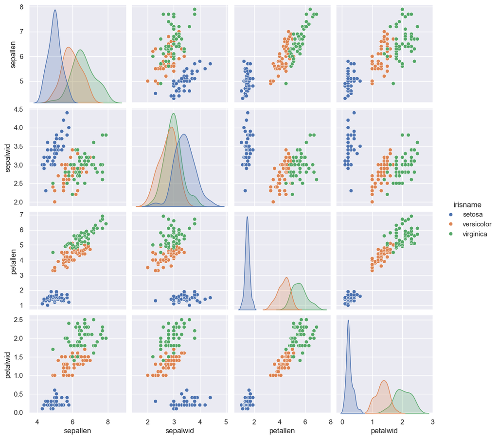

```python
# To illustrate the beauty of data visualization...
# Let's start with perhaps the most powerful type of plot applicable to this data set: a pair plot

# The POWER of seaborn: one-line code
PairPlot = sns.pairplot(data=iris, hue='irisname')
# Making graphs has never been easier!

# Unpacking this...
# pairplot() is the function that - you guessed it - makes the pairplot
# 'data' is ... where the data comes from (our pandas data frame)
# 'hue' colors the dots based on values in the designated ('Species') column in the data frame

# What on Earth is a pair plot?
# A scatter plot compares two values (i.e. length and width)
# A pair plot simply creates a scatter plot of every possible pair of values
# You can see which values are being compared by looking at the labels!
# The diagonal plots however are simply the distribution of a single value (a 'univariate' distribution)

# Why did we name the plot?
# Without a name, an not-very-informative storage location (?) gets printed at the top of the graph...
```

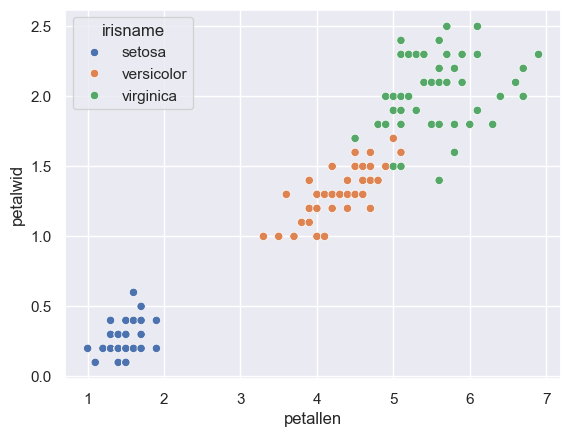

```python
# Now we know how striking Seaborn and data visualization can be
# Let's explore the relationship between petal length and petal width using a single scatter plot

ScatterPlot = sns.scatterplot(x='petallen', y='petalwid', data=iris, hue='irisname')

# Unpacking this...
# scatterplot() is the function that - you guessed it - makes the scatterplot
# 'x' is ... the data for the x axis
# 'y' is ... the data for the y axis

# Can you find this graph in the pair plot?
```

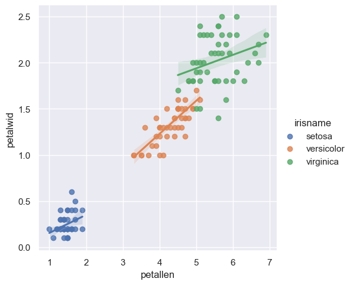

```python
# We see that there may be some kind of linear relationship between these variables!
# We can use a lmplot (linear model) to add regression lines to the data

LmPlot = sns.lmplot(x='petallen', y='petalwid', data=iris, hue = 'irisname')

# If you add the 'hue' parameter, the data will become separated by species and you can view the best-fit line for each species
```

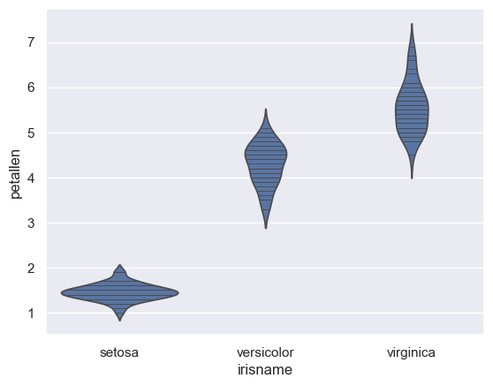

```python
# Let's try something else now...
# Which flowers have the longest petals?
# You could create something like a dot plot or a box plot, but let's try a more musical approach:

ViolinPlot = sns.violinplot(x='irisname', y='petallen', data=iris, inner='stick')

# Unpacking this...
# 'inner' draws a stick for each data point
# Notice that the plots get wider in areas with more sticks!

# A violin plot is very similar to a box-and-whiskers plot, but has more detail (and is much cooler)
```

### Let's see an example of my favorite visualization, the *heat map*!

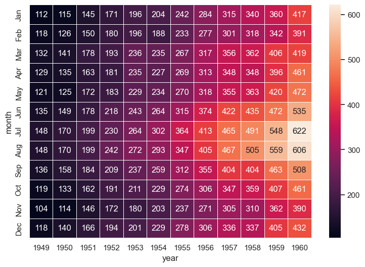

```python
import matplotlib.pyplot as plt
import seaborn as sns
sns.set_theme()

# Load the example flights dataset and convert to long-form
flights_long = sns.load_dataset("flights")
flights = (
    flights_long
    .pivot(index="month", columns="year", values="passengers")
)

# Draw a heatmap with the numeric values in each cell
f, ax = plt.subplots(figsize=(9, 6))
sns.heatmap(flights, annot=True, fmt="d", linewidths=.5, ax=ax)
```

### Let's adapt the heatmap to show an example digit-image!

```
pixels as 1d numpy array (row):
 [ 0  0  7 13 11  0  0  0  0  6 16 11 16  0  0  0  0  3  8  5 16  0  0  0
  0  0  3 15 16  6  0  0  0  0  0  7  8 16  5  0  0  6  8  0  0 11  9  0
  0  0 16  6  6 14  6  0  0  0  6 15 16 10  0  0]

pixels as 2d numpy array (image):
 [[ 0  0  7 13 11  0  0  0]
 [ 0  6 16 11 16  0  0  0]
 [ 0  3  8  5 16  0  0  0]
 [ 0  0  3 15 16  6  0  0]
 [ 0  0  0  7  8 16  5  0]
 [ 0  6  8  0  0 11  9  0]
 [ 0  0 16  6  6 14  6  0]
 [ 0  0  6 15 16 10  0  0]]
```

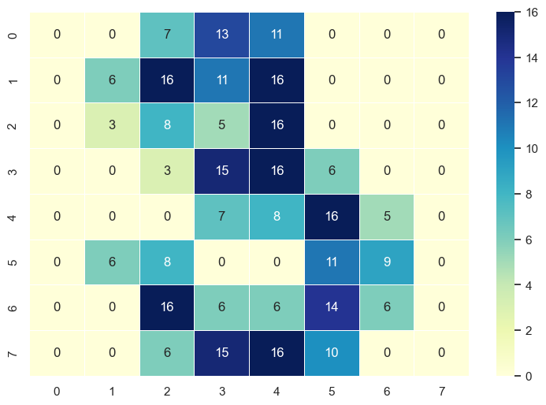

```python
import matplotlib.pyplot as plt
import seaborn as sns
import pandas as pd
import numpy as np
sns.set_theme()

# Load the example flights dataset and convert to long-form
digits_orig = pd.read_csv('./digits.csv')
list_of_column_names = digits_orig.columns

ROW = 0
COLUMN = 1
digits2 = digits_orig.drop( list_of_column_names[-1], axis=COLUMN)  # drop the rightmost column - it's just a url!
digitsA = digits2.values  # get a numpy array (digitsA) from the dataframe (digits2)

row_to_show = 440   # choose the digit (row) you want to show...

pixels_as_row = digitsA[row_to_show,0:64]
print("pixels as 1d numpy array (row):\n", pixels_as_row)

pixels_as_image = np.reshape(pixels_as_row, (8,8))   # reshape into a 2d 8x8 array (image)
print("\npixels as 2d numpy array (image):\n", pixels_as_image)

# create the figure, f, and the axes, ax:
f, ax = plt.subplots(figsize=(9, 6))

# colormap choice! Fun!   www.practicalpythonfordatascience.com/ap_seaborn_palette or seaborn.pydata.org/tutorial/color_palettes.html
our_colormap = sns.color_palette(palette='YlGnBu', as_cmap=True)

# Draw a heatmap with the numeric values in each cell (make annot=False to remove the values)
sns.heatmap(pixels_as_image, annot=True, fmt="d", linewidths=.5, ax=ax, cmap=our_colormap)
```

As you can see, seaborn provides a resource for creating informative plots from a dataframe...

## hw4pr1, task #2:

#### Your task...

- Is to check out https://seaborn.pydata.org/examples/index.html - or other Galleries - for more ideas that might strike your interest...
  - the two examples, below, don't "count" - but they do show the idea
  - **be sure to include a name and a url to your source for each**
- Then, create three (or more) additional plots from those galleries.
- Using their data is 100% ok. This is really curated exploration...
  - Which is to say, it's *Copy-and-Paste* (CaP is a very good friend! :-)
- Other galleries of examples:
  - matplotlib: https://matplotlib.org/2.0.2/gallery.html
  - python graph gallery: https://python-graph-gallery.com/
- *Task #3*, below, asks you to adapt your choice of visualizations to our other datasets...
  - ... and at least one dataset of your own.

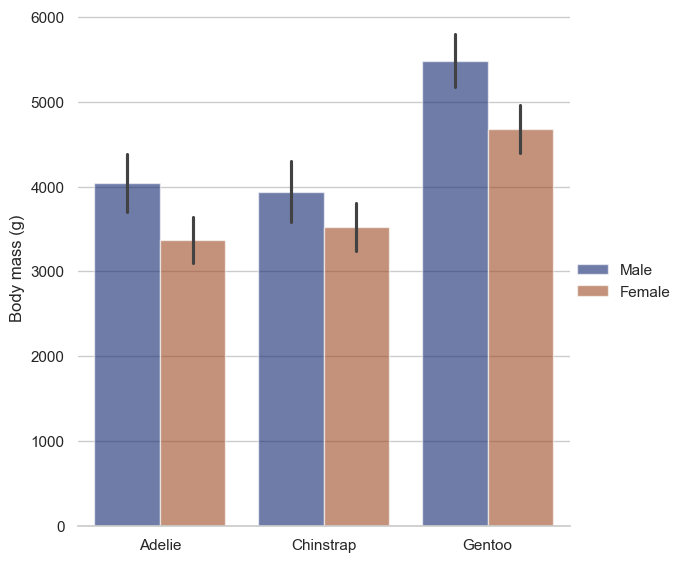

```python
#
# seaborn gallery penguin example from
#    https://seaborn.pydata.org/examples/grouped_barplot.html

import seaborn as sns
sns.set_theme(style="whitegrid")

penguins = sns.load_dataset("penguins")

# Draw a nested barplot by species and sex
g = sns.catplot(
    data=penguins, kind="bar",
    x="species", y="body_mass_g", hue="sex",
    errorbar="sd", palette="dark", alpha=.6, height=6
)
g.despine(left=True)
g.set_axis_labels("", "Body mass (g)")
g.legend.set_title("")
```

```python
# restarting the kernel... (I'm not sure why this is here. -ZD)

# from IPython.core.display import HTML
# HTML("<script>Jupyter.notebook.kernel.restart()</script>")
```

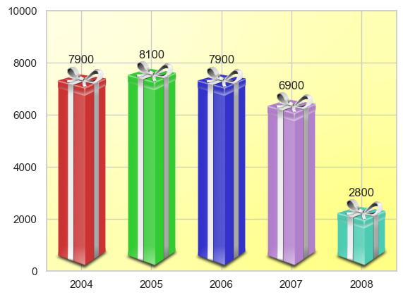

```python
#
# the ribbon box example from
#     https://matplotlib.org/stable/gallery/misc/demo_ribbon_box.html
#

import numpy as np

from matplotlib import cbook, colors as mcolors
from matplotlib.image import AxesImage
import matplotlib.pyplot as plt
from matplotlib.transforms import Bbox, TransformedBbox, BboxTransformTo


class RibbonBox:

    original_image = plt.imread(
        cbook.get_sample_data("Minduka_Present_Blue_Pack.png"))
    cut_location = 70
    b_and_h = original_image[:, :, 2:3]
    color = original_image[:, :, 2:3] - original_image[:, :, 0:1]
    alpha = original_image[:, :, 3:4]
    nx = original_image.shape[1]

    def __init__(self, color):
        rgb = mcolors.to_rgb(color)
        self.im = np.dstack(
            [self.b_and_h - self.color * (1 - np.array(rgb)), self.alpha])

    def get_stretched_image(self, stretch_factor):
        stretch_factor = max(stretch_factor, 1)
        ny, nx, nch = self.im.shape
        ny2 = int(ny*stretch_factor)
        return np.vstack(
            [self.im[:self.cut_location],
             np.broadcast_to(
                 self.im[self.cut_location], (ny2 - ny, nx, nch)),
             self.im[self.cut_location:]])


class RibbonBoxImage(AxesImage):
    zorder = 1

    def __init__(self, ax, bbox, color, *, extent=(0, 1, 0, 1), **kwargs):
        super().__init__(ax, extent=extent, **kwargs)
        self._bbox = bbox
        self._ribbonbox = RibbonBox(color)
        self.set_transform(BboxTransformTo(bbox))

    def draw(self, renderer, *args, **kwargs):
        stretch_factor = self._bbox.height / self._bbox.width

        ny = int(stretch_factor*self._ribbonbox.nx)
        if self.get_array() is None or self.get_array().shape[0] != ny:
            arr = self._ribbonbox.get_stretched_image(stretch_factor)
            self.set_array(arr)

        super().draw(renderer, *args, **kwargs)


def main():
    fig, ax = plt.subplots()

    years = np.arange(2004, 2009)
    heights = [7900, 8100, 7900, 6900, 2800]
    box_colors = [
        (0.8, 0.2, 0.2),
        (0.2, 0.8, 0.2),
        (0.2, 0.2, 0.8),
        (0.7, 0.5, 0.8),
        (0.3, 0.8, 0.7),
    ]

    for year, h, bc in zip(years, heights, box_colors):
        bbox0 = Bbox.from_extents(year - 0.4, 0., year + 0.4, h)
        bbox = TransformedBbox(bbox0, ax.transData)
        ax.add_artist(RibbonBoxImage(ax, bbox, bc, interpolation="bicubic"))
        ax.annotate(str(h), (year, h), va="bottom", ha="center")

    ax.set_xlim(years[0] - 0.5, years[-1] + 0.5)
    ax.set_ylim(0, 10000)

    background_gradient = np.zeros((2, 2, 4))
    background_gradient[:, :, :3] = [1, 1, 0]
    background_gradient[:, :, 3] = [[0.1, 0.3], [0.3, 0.5]]  # alpha channel
    ax.imshow(background_gradient, interpolation="bicubic", zorder=0.1,
              extent=(0, 1, 0, 1), transform=ax.transAxes, aspect="auto")

    plt.show()


main()
```

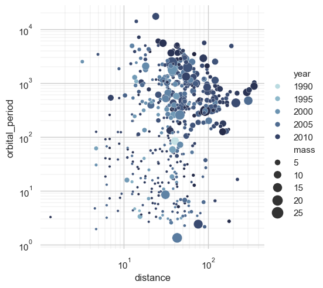

```python
"""
=================================
1. Seaborn three variable scatterplot
https://seaborn.pydata.org/examples/scatterplot_sizes.html
=================================

"""
import seaborn as sns
sns.set_theme(style="whitegrid")

# Load the example planets dataset
planets = sns.load_dataset("planets")

cmap = sns.cubehelix_palette(rot=-.2, as_cmap=True)
g = sns.relplot(
    data=planets,
    x="distance", y="orbital_period",
    hue="year", size="mass",
    palette=cmap, sizes=(10, 200),
)
g.set(xscale="log", yscale="log")
g.ax.xaxis.grid(True, "minor", linewidth=.25)
g.ax.yaxis.grid(True, "minor", linewidth=.25)
g.despine(left=True, bottom=True)
```

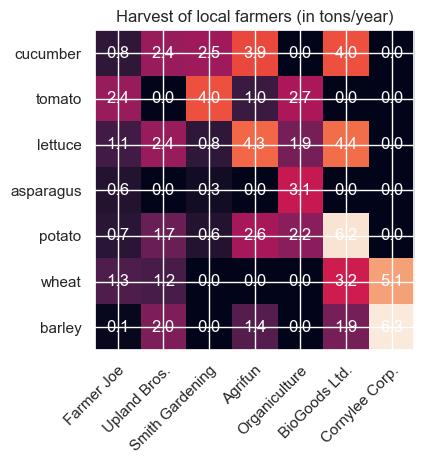

```python
"""
=================================
2. Matplotlib annotated heatmap
https://matplotlib.org/stable/gallery/images_contours_and_fields/image_annotated_heatmap.html#sphx-glr-gallery-images-contours-and-fields-image-annotated-heatmap-py
=================================

"""
import matplotlib.pyplot as plt
import numpy as np

import matplotlib
import matplotlib as mpl


vegetables = ["cucumber", "tomato", "lettuce", "asparagus",
              "potato", "wheat", "barley"]
farmers = ["Farmer Joe", "Upland Bros.", "Smith Gardening",
           "Agrifun", "Organiculture", "BioGoods Ltd.", "Cornylee Corp."]

harvest = np.array([[0.8, 2.4, 2.5, 3.9, 0.0, 4.0, 0.0],
                    [2.4, 0.0, 4.0, 1.0, 2.7, 0.0, 0.0],
                    [1.1, 2.4, 0.8, 4.3, 1.9, 4.4, 0.0],
                    [0.6, 0.0, 0.3, 0.0, 3.1, 0.0, 0.0],
                    [0.7, 1.7, 0.6, 2.6, 2.2, 6.2, 0.0],
                    [1.3, 1.2, 0.0, 0.0, 0.0, 3.2, 5.1],
                    [0.1, 2.0, 0.0, 1.4, 0.0, 1.9, 6.3]])


fig, ax = plt.subplots()
im = ax.imshow(harvest)

# Show all ticks and label them with the respective list entries
ax.set_xticks(range(len(farmers)), labels=farmers,
              rotation=45, ha="right", rotation_mode="anchor")
ax.set_yticks(range(len(vegetables)), labels=vegetables)

# Loop over data dimensions and create text annotations.
for i in range(len(vegetables)):
    for j in range(len(farmers)):
        text = ax.text(j, i, harvest[i, j],
                       ha="center", va="center", color="w")

ax.set_title("Harvest of local farmers (in tons/year)")
fig.tight_layout()
plt.show()
```

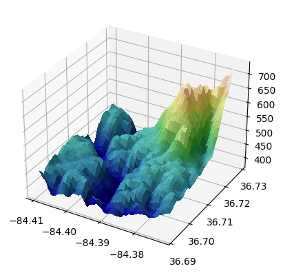

```python
"""
=================================
3. Matplotlib 3d surface visual
https://matplotlib.org/stable/gallery/mplot3d/custom_shaded_3d_surface.html#sphx-glr-gallery-mplot3d-custom-shaded-3d-surface-py
=================================

"""

import matplotlib.pyplot as plt
import numpy as np

from matplotlib import cbook, cm
from matplotlib.colors import LightSource

# Load and format data
dem = cbook.get_sample_data('jacksboro_fault_dem.npz')
z = dem['elevation']
nrows, ncols = z.shape
x = np.linspace(dem['xmin'], dem['xmax'], ncols)
y = np.linspace(dem['ymin'], dem['ymax'], nrows)
x, y = np.meshgrid(x, y)

region = np.s_[5:50, 5:50]
x, y, z = x[region], y[region], z[region]

# Set up plot
fig, ax = plt.subplots(subplot_kw=dict(projection='3d'))

ls = LightSource(270, 45)
# To use a custom hillshading mode, override the built-in shading and pass
# in the rgb colors of the shaded surface calculated from "shade".
rgb = ls.shade(z, cmap=cm.gist_earth, vert_exag=0.1, blend_mode='soft')
surf = ax.plot_surface(x, y, z, rstride=1, cstride=1, facecolors=rgb,
                       linewidth=0, antialiased=False, shade=False)

plt.show()
```

### hw4pr1, task #2b:

#### The final visualization-task for this week...

We will be using `births`, `iris`, `digits`, and `titanic` to practice the data-modeling workflows and algoithms in the upcoming weeks. *In addition*, you will apply those modeling techniques to your own datasets... .

#### Feel free to create **fundamental** plots - line plots, scatter plots, histograms...

Specifically, these plots do not need to be - indeed, *should not* be - especially complex or intricate

- Intricate and complex plots are wonderful, but lines, points, and bars are the starting point for most dataset understanding
- in fact, they're the starting point for most of the intricate, complex plots, as well!

#### Example dataset visualization

This one uses the `iris.csv` dataset.

Here, we read the file and preprocess it, as we did above:

```python
# We import import our dataframe from a csv, using pandas
iris_orig = pd.read_csv('./iris.csv')
# iris_orig

ROW = 0
COLUMN = 1

iris2 = iris_orig.drop('adapted from https://en.wikipedia.org/wiki/Iris_flower_data_set', axis=COLUMN)
# iris2

# Those last two rows look suspicious...
iris3 = iris2.drop(142, axis=ROW)
iris4 = iris3.drop(141, axis=ROW)
iris = iris4
iris                 # our final dataframe-name
```

|  | sepallen | sepalwid | petallen | petalwid | irisname |
| --- | --- | --- | --- | --- | --- |
| 0 | 4.6 | 3.6 | 1.0 | 0.2 | setosa |
| 1 | 4.3 | 3.0 | 1.1 | 0.1 | setosa |
| 2 | 5.0 | 3.2 | 1.2 | 0.2 | setosa |
| 3 | 5.8 | 4.0 | 1.2 | 0.2 | setosa |
| 4 | 4.4 | 3.0 | 1.3 | 0.2 | setosa |
| ... | ... | ... | ... | ... | ... |
| 136 | 7.9 | 3.8 | 6.4 | 2.0 | virginica |
| 137 | 7.6 | 3.0 | 6.6 | 2.1 | virginica |
| 138 | 7.7 | 3.8 | 6.7 | 2.2 | virginica |
| 139 | 7.7 | 2.8 | 6.7 | 2.0 | virginica |
| 140 | 7.7 | 2.6 | 6.9 | 2.3 | virginica |

141 rows × 5 columns

Let's sort by the **petalwid** column and then plot that!

```python
iris_sorted = iris.sort_values(by=['petalwid'])
iris_sorted
```

|  | sepallen | sepalwid | petallen | petalwid | irisname |
| --- | --- | --- | --- | --- | --- |
| 1 | 4.3 | 3.0 | 1.1 | 0.1 | setosa |
| 24 | 4.9 | 3.1 | 1.5 | 0.1 | setosa |
| 14 | 4.8 | 3.0 | 1.4 | 0.1 | setosa |
| 25 | 4.9 | 3.1 | 1.5 | 0.1 | setosa |
| 26 | 4.9 | 3.1 | 1.5 | 0.1 | setosa |
| ... | ... | ... | ... | ... | ... |
| 102 | 5.8 | 2.8 | 5.1 | 2.4 | virginica |
| 122 | 6.7 | 3.1 | 5.6 | 2.4 | virginica |
| 119 | 6.3 | 3.4 | 5.6 | 2.4 | virginica |
| 132 | 7.2 | 3.6 | 6.1 | 2.5 | virginica |
| 124 | 6.7 | 3.3 | 5.7 | 2.5 | virginica |

141 rows × 5 columns

```python
#
# let's create a new column with integer values from 0 to the length of the dataframe:

iris_sorted['x_value'] = np.arange(0,len(iris_sorted))   # this is like an "index," but it's just values
iris_sorted
```

|  | sepallen | sepalwid | petallen | petalwid | irisname | x_value |
| --- | --- | --- | --- | --- | --- | --- |
| 1 | 4.3 | 3.0 | 1.1 | 0.1 | setosa | 0 |
| 24 | 4.9 | 3.1 | 1.5 | 0.1 | setosa | 1 |
| 14 | 4.8 | 3.0 | 1.4 | 0.1 | setosa | 2 |
| 25 | 4.9 | 3.1 | 1.5 | 0.1 | setosa | 3 |
| 26 | 4.9 | 3.1 | 1.5 | 0.1 | setosa | 4 |
| ... | ... | ... | ... | ... | ... | ... |
| 102 | 5.8 | 2.8 | 5.1 | 2.4 | virginica | 136 |
| 122 | 6.7 | 3.1 | 5.6 | 2.4 | virginica | 137 |
| 119 | 6.3 | 3.4 | 5.6 | 2.4 | virginica | 138 |
| 132 | 7.2 | 3.6 | 6.1 | 2.5 | virginica | 139 |
| 124 | 6.7 | 3.3 | 5.7 | 2.5 | virginica | 140 |

141 rows × 6 columns

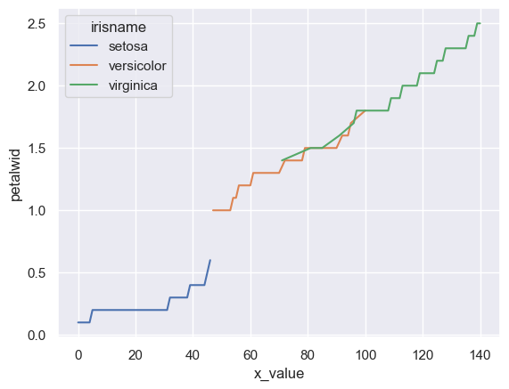

```python
#
# Now, let's plot the petalwidths against their location in the sorted list:

import seaborn as sns
sns.set_theme(style="darkgrid")

# Plot the responses for different events and regions
sns.lineplot(x="x_value",y="petalwid", hue="irisname", data=iris_sorted)
```

Interesting... It seems that the setosa species have narrow petals, then versicolor, then virginica...

- with some overlap in the last two...

Create cells below for your own, *foundational* data-visualizations:

- from 2-3 of our four other datasets (`births`, `iris`, `digits`, and `titanic`)
- and one of your own

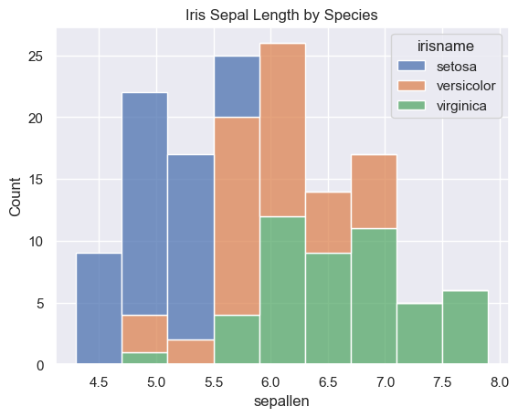

```python
"""
=================================
1. Histogram (Iris)
=================================

"""
import seaborn as sns
import pandas as pd

irisdata = pd.read_csv('iris_cleaned.csv')   # read iris file

sns.set_theme(style="darkgrid")
sns.histplot(
    data = irisdata, x = "sepallen",         # from iris data, make histogram w/ sepal length
    hue = "irisname",                        # separate species by color
    multiple = "stack",                      # have colors be solid and not overlapping half transparent

).set_title("Iris Sepal Length by Species")  # title
```

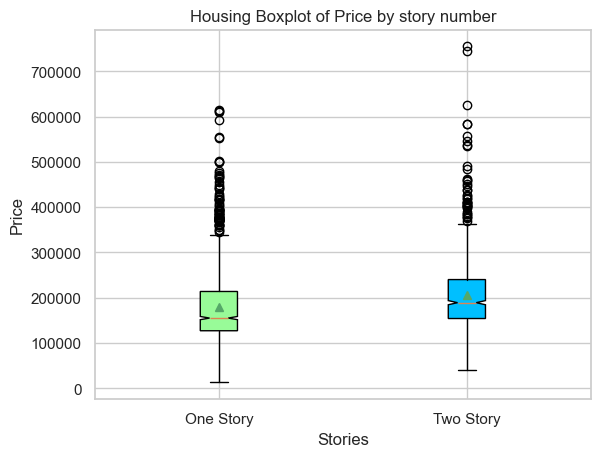

```python
"""
=================================
2. Box plots (Housing)
=================================

"""
import numpy as np
import matplotlib.pyplot as plt
import seaborn as sns

housing = pd.read_csv('housing.csv')       # read files

colors = ['palegreen', 'deepskyblue']      # boxplot color/label customization
labels = ['One Story', 'Two Story']

onestory = housing.loc[housing['House Style'] == '1Story']     # extract data by # of house stories
twostory = housing.loc[housing['House Style'] == '2Story']

data = [onestory['SalePrice'], twostory['SalePrice']]          # extract prices from each house story dataset


box = plt.boxplot(data, tick_labels=labels, showmeans=True, notch=True, patch_artist = True) # notched boxplot w/ colored mean & customizations above
for patch, color in zip(box['boxes'], colors):
    patch.set_facecolor(color)
plt.title('Housing Boxplot of Price by story number')
plt.xlabel('Stories')
plt.ylabel('Price')
plt.show()
```

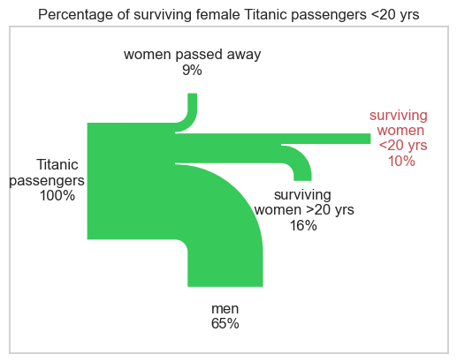

```python
"""
================
3. Sankey (Titanic)
================

"""

import numpy as np
import matplotlib.pyplot as plt
import seaborn as sns

from matplotlib.sankey import Sankey

titanic = sns.load_dataset("titanic")

man_count = len(titanic.loc[titanic['sex']=="male"])                            # automated finding of percentages for passenger features
man_percent = ((man_count) / len(titanic['sex'])) * 100                         # to end up with percent of passengers who're surviving women <20

woman = titanic.loc[titanic['sex']=="female"]                                   # eliminate men, women who passed away, and surviving women >20
women_passed = woman.loc[woman['survived']==0]
women_passed_percent = ((len(women_passed)) / (len(titanic['sex']))) * 100

women_survived = woman.loc[woman['survived']==1]
gtwenty_survived = len(women_survived.loc[women_survived['age'] >= 20])
gtwenty_survived_percent = (gtwenty_survived/ len(titanic['sex'])) * 100

under_twenty_percent = 100 - (gtwenty_survived_percent + women_passed_percent + man_percent)

fig = plt.figure()
ax = fig.add_subplot(1, 1, 1, xticks=[], yticks=[],                                         # one plot no ticks
                     title="Percentage of surviving female Titanic passengers <20 yrs")     # plot title
sankey = Sankey(ax=ax, scale=0.01, offset=0.25, head_angle=180,                             # set direction, label dist, and axes. also set % formatting
                format='%.0f', unit='%')
sankey.add(flows=[100, -gtwenty_survived_percent, -women_passed_percent, -man_percent, -under_twenty_percent],    #
           labels=['Titanic\npassengers     ', 'surviving\n women >20 yrs', 'women passed away', 'men', 'surviving \n women \n <20 yrs'],
           orientations=[0, -1, 1, -1, 0],
           pathlengths=[0.1, 0.15, 0.25, 0.4, 0.5], facecolor='#37c959')
diagrams = sankey.finish()
diagrams[0].texts[-1].set_color('r')
diagrams[0].text.set_fontweight('bold')

plt.show()
```

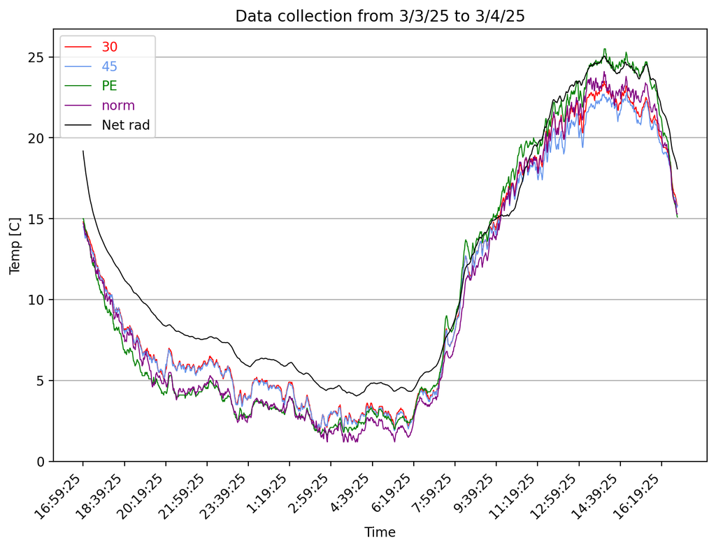

```python
"""
================
4. My own data set!
================

"""

import matplotlib.pyplot as plt
import pandas as pd
import numpy as np

tcdata = pd.read_csv('30-45 run 3:4:2025.csv')   # read data files
tcdata = tcdata.set_index('Place')               # make sure Place can be used as an index


tcstart_run = tcdata[tcdata.index >= 10606]                    # select data points to graph - numbers have to be changed every run
tclast_run = tcstart_run[tcstart_run.index <= 12044]           # coud probably find a better way to do this


fig, axs = plt.subplots(figsize=(9, 6), dpi=200)               # figure size & resolution


axs.plot(tclast_run['Time'], tclast_run['30'], label='30', color = 'red', linewidth=.75)                    # thermocouple data
axs.plot(tclast_run['Time'], tclast_run['45'], label='45', color = 'cornflowerblue', linewidth=.75)
axs.plot(tclast_run['Time'], tclast_run['PE'], label='PE', color = 'green', linewidth=.75)
axs.plot(tclast_run['Time'], tclast_run['norm'], label='norm', color = 'purple', linewidth=.75)
axs.plot(tclast_run['Time'], tclast_run[' label'], label='Net rad', color = 'black', linewidth=.75)         # inserted net radiometer data
axs.legend(labelcolor=['red', 'cornflowerblue', 'green', 'purple', 'black'])                                # set unique colors for each line


ticks = tclast_run['Time'][::100]                                     # only show some x-axis labels, every 100th value
axs.set_xticks(ticks)
axs.set_xticklabels(ticks, rotation=45, horizontalalignment='right')  # have labels be slanted for readability


axs.grid(True, axis='y')                                              # y-axis gridlines


axs.set_title('Data collection from 3/3/25 to 3/4/25')       # title
axs.set_ylabel(r'Temp [C]')                                  # y-axis
axs.set_xlabel(r'Time')                                      # x-axis


plt.show()
```

`I used this homework assignment to help with my research! We run a lot of 24 hr temperature collection trials, and I typically make plots in excel, but I thought it would be nice to have one bit of code that I can use to read any collected data file. Making this graphing function actually be able to do that is still a work in progress... and will definitely take some more time but this was a good start. I've been meaning to learn how to do this for a while now so I'm glad this homework assignment got me to actually get started with it :)`

As you can see, seaborn provides a resource for creating informative plots from a dataframe...

Next, we dive into model-building, whose goal is to create predictive/explanatory models from the data.

## Part (c): Model-building!

#### Linear Regression hw4pr1, part c

- *Linear Regression* is sometimes considered the "first" approach to model-building.
- Indeed, it's fast, and it's powerful.
- A few **limitations** of linear regression:
  - By default, linear regression predicts *continuous* variables (features) from other *continuous* features
  - For example, you'll see below that we create a Linear Regression model to predict flowers' `sepalwid` from their `petallen`
  - Also, Linear Regression makes the strong assumption that the input-output relationship is linear...
    - In practice, this means that doubling the input will double the output (and halving the input will halve the output), after accounting for the average offset
  - Not every relationship **is** linear -- but many are.
  - Plus, we can always just treat a relationship as linear -- just to see how well or poorly that approximation does!
- On the whole, linear regression has a lot more positives than negatives!
- Here are some **upsides** of linear regression:
  - Every modeling library has already implemented it for you! (we will use `scikit-learn`)
  - It can handle any number of dimensions of input and output.
    - A one-dimensional regression (one input and one output) is a *line*.
    - A two-dimensional regression (two inputs and one output) is a *plane*.
    - More dimensions are harder to visualize. They're usually called *hyperplanes*. I imagine them as just planes for which you can swap different input features.
- *Part (c)*, below, asks you to first run this example of linear regression of `sepalwid` vs. `petallen` in the `iris.csv` flower data.
  - Then, **adapt this example to at least one dataset of your own**. totally optional EC for adding, too, an example with inputs that are 2d or more

```python
# Load the iris data from iris_cleaned.csv
iris_df = pd.read_csv('iris_cleaned.csv')   # this is a dataframe
```

```python
iris_df
```

|  | sepallen | sepalwid | petallen | petalwid | irisname |
| --- | --- | --- | --- | --- | --- |
| 0 | 4.6 | 3.6 | 1.0 | 0.2 | setosa |
| 1 | 4.3 | 3.0 | 1.1 | 0.1 | setosa |
| 2 | 5.0 | 3.2 | 1.2 | 0.2 | setosa |
| 3 | 5.8 | 4.0 | 1.2 | 0.2 | setosa |
| 4 | 4.4 | 3.0 | 1.3 | 0.2 | setosa |
| ... | ... | ... | ... | ... | ... |
| 136 | 7.9 | 3.8 | 6.4 | 2.0 | virginica |
| 137 | 7.6 | 3.0 | 6.6 | 2.1 | virginica |
| 138 | 7.7 | 3.8 | 6.7 | 2.2 | virginica |
| 139 | 7.7 | 2.8 | 6.7 | 2.0 | virginica |
| 140 | 7.7 | 2.6 | 6.9 | 2.3 | virginica |

141 rows × 5 columns

```python
# loop over all rows -- easier than trying to change how pandas displays the summary
for row in iris_df.iterrows():
    print(row)
```

[output not shown]

[output cut: 791 more lines]

[output not shown]

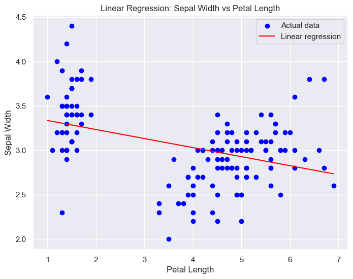

```
Slope: -0.1019
Intercept: 3.4374
```

```python
# Create a Linear Regression model
from sklearn.linear_model import LinearRegression

# Create and fit the model
model = LinearRegression()
X = iris_df[['petallen']].values  # Input feature as 2D array
y = iris_df['sepalwid'].values    # Target variable as 1D array
model.fit(X, y)

# Make predictions using the model
y_pred = model.predict(X)

# Plot the results
plt.figure(figsize=(8, 6))
plt.scatter(X, y, color='blue', label='Actual data')
plt.plot(X, y_pred, color='red', label='Linear regression')
plt.xlabel('Petal Length')
plt.ylabel('Sepal Width')
plt.title('Linear Regression: Sepal Width vs Petal Length')
plt.legend()
plt.show()

# Print the model coefficients
print(f"Slope: {model.coef_[0]:.4f}")
print(f"Intercept: {model.intercept_:.4f}")
```

```python
# Calculate R-squared score
r2_score = model.score(X, y)
print(f"R-squared score: {r2_score:.4f}")
```

```
R-squared score: 0.1749
```

```python
def predict_sepal_width(petal_length):
    """
    Predicts sepal width based on petal length using the trained linear regression model

    Args:
        petal_length (float): The petal length value to make prediction for

    Returns:
        float: Predicted sepal width value
    """
    # Reshape input to 2D array with 1 sample, 1 feature
    X_new = [[petal_length]]

    # Use model to make prediction
    prediction = model.predict(X_new)

    # Return the predicted value
    return prediction[0]

# Test the function with a sample value
test_petal_length = 2.5
predicted_width = predict_sepal_width(test_petal_length)
print(f"For a petal length of {test_petal_length}, predicted sepal width is {predicted_width:.2f}")
```

```
For a petal length of 2.5, predicted sepal width is 3.18
```

### Hooray! Our predictive model is complete!

Let's note that

- It's really not a very good model.
- An R-squared value of 0.17 means that
  - only 17% of the variance in the output `sepalwid` is explained by the input `petallen`
  - this means that modeling-by-just-using-the-average is almost as good!

To be honest, I was expecting the relationship to be stronger. Because it's so weak,

- My very naive self takes this as evidence that the petal and sepal are more different - in their biological function - than I'd previously imagined.
  - I had figured sepals were just "more petals" ... but apparently ... the petals are for structure/support and the sepals are "landing pads" to attract bees to the flower. Ok!

Just for illustration, let's create a "model-by-just-using-the-average" - it's below.

- Note, that this is not needed for your model. It's good to know it's there!

```python
def predict_sepal_width_via_avg(petal_length=4.2):
    """
    Predicts sepal width by simply returning the average sepal width,
    ignoring the input petal length

    Args:
        petal_length (float): The petal length value (ignored)

    Returns:
        float: Average sepal width value
    """
    # Calculate average sepal width from training data
    avg_sepal_width = iris_df['sepalwid'].mean()

    # Return the average, regardless of input
    return avg_sepal_width

# Test the function with same sample value
test_petal_length = 2.5
predicted_width_avg = predict_sepal_width_via_avg(test_petal_length)
print(f"For a petal length of {test_petal_length}, predicted sepal width (using average) is {predicted_width_avg:.2f}")
```

```
For a petal length of 2.5, predicted sepal width (using average) is 3.05
```

#### A second example:

Let's run the "very first" linear regression ... ?!

This uses the dataset of 1078 heights -- from the 1890's/1900's.

```python
# Let's run a linear regression on the pearson dataset

import pandas as pd
pearson_df = pd.read_csv('./pearson_dataset.csv')
pearson_df
```

|  | fheight | sheight |
| --- | --- | --- |
| 0 | 65.04851 | 59.77827 |
| 1 | 63.25094 | 63.21404 |
| 2 | 64.95532 | 63.34242 |
| 3 | 65.75250 | 62.79238 |
| 4 | 61.13723 | 64.28113 |
| ... | ... | ... |
| 1073 | 66.99681 | 70.75232 |
| 1074 | 71.33181 | 68.26774 |
| 1075 | 71.78314 | 69.30589 |
| 1076 | 70.73837 | 69.30199 |
| 1077 | 70.30609 | 67.01500 |

1078 rows × 2 columns

```
R-squared: 0.2513
Slope: 0.4889
Intercept: 34.1075
```

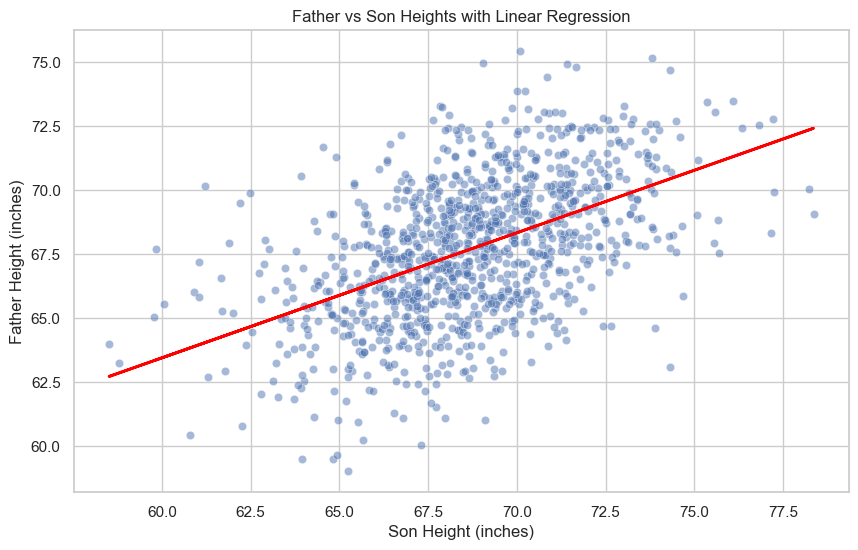

```python
import matplotlib.pyplot as plt
import seaborn as sns

# Create scatter plot of heights data
plt.figure(figsize=(10,6))
sns.scatterplot(data=pearson_df, x='sheight', y='fheight', alpha=0.5)

# Fit linear regression
from sklearn.linear_model import LinearRegression
X = pearson_df[['sheight']].values
y = pearson_df['fheight'].values
reg = LinearRegression().fit(X, y)

# Plot regression line
plt.plot(X, reg.predict(X), color='red', linewidth=2)

plt.title('Father vs Son Heights with Linear Regression')
plt.xlabel('Son Height (inches)')
plt.ylabel('Father Height (inches)')

# Calculate and print R-squared, slope and intercept
r2 = reg.score(X, y)
slope = reg.coef_[0]
intercept = reg.intercept_

print(f"R-squared: {r2:.4f}")
print(f"Slope: {slope:.4f}")
print(f"Intercept: {intercept:.4f}")
```

How did it do?

- It worked!
- The model is compelling, but not particularly strong (R-squared about 0.25)
  - This makes sense: height is loosely, but only loosely, correlated with parent height
- One wonders if the overall average continues to rise. (I suspect so...)
- Key takeaway: **regression** is a historical name, not a helpfully suggestive one, for the process of *building a model with floating-point outputs, i.e., continuous outputs*
  - Very often there's no "regression" to any mean -- or any "regression" to anything at all. Just continuous outputs...

### *Part (c)* Your own regression...

Take it away! From here, **adapt this example to build a linear-regression model for at least one dataset of your own**:

- Choose a different dataset than the iris and pearson datasets...
- Choose any two *continuous* features -- that is, features with varying numeric values *in which their relative values are meaningful*
  - Numeric values that are simply an encoding for different labels are **not** continuous features.
- Be sure to run at least one 1d linear regression.
- Be sure to create a short markdown cell that reflects on how well/poorly your model does...
  - What is the R-squared value?
  - Is it surprising that the linear model does well for your example?
  - Or would that be something you expected. in your case?
- totally optional EC for adding, a second Linear-Regression example with inputs that are two-dimensional or higher

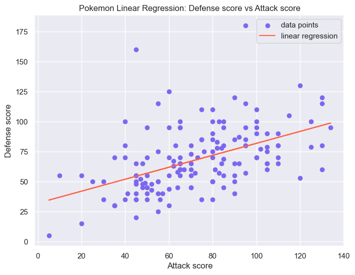

[output not shown]

```python
import pandas as pd
from sklearn.linear_model import LinearRegression

pmdata = pd.read_csv('Pokemon.csv', encoding = "ISO-8859-1") # had to change from standard csv b/c of undecodable char.. thanks stack xchange!

# Create and fit the model
pokemodel = LinearRegression()
X = pmdata[['Attack']].values  # Input feature as 2D array
y = pmdata['Defense'].values    # Target variable as 1D array
pokemodel.fit(X, y)

# Make predictions using the model
y_pred = pokemodel.predict(X)

# Plot the results
plt.figure(figsize=(8, 6))
plt.scatter(X, y, color='mediumslateblue', label='data points')
plt.plot(X, y_pred, color='tomato', label='linear regression')
plt.xlabel('Attack score')
plt.ylabel('Defense score')
plt.title('Pokemon Linear Regression: Defense score vs Attack score')
plt.legend()
plt.show()

# Print the model coefficients
print(f"Slope: {pokemodel.coef_[0]:.4f}")
print(f"Intercept: {pokemodel.intercept_:.4f}")

poker2_score = pokemodel.score(X, y)
print(f"R-squared score: {poker2_score:.4f}")

def predict_attack_score(defense):
    """
    Predicts pokemon attack score using the trained linear regression model

    Args:
        defense (int): The defense score to make prediction for

    Returns:
        float: Predicted attack score
    """
    # Reshape input to 2D array with 1 sample, 1 feature
    PokeX_new = [[defense]]

    # Use model to make prediction
    pokeprediction = pokemodel.predict(PokeX_new)

    # Return the predicted value
    return pokeprediction[0]

# Test the function with a sample value
testdefense = 66
predicted_defense = predict_attack_score(testdefense)
print(f"For a defense score of {testdefense}, predicted attack score is {predicted_defense:.2f}")
```

##### Linear Regression Results

- Be sure to create a short markdown cell that reflects on how well/poorly your model does...
  - R-squared = 0.24... not so good
  - I did expect a very different trend, perhaps because I don't completely understand Pokemon stats. I thought defense and attack would be inversely proportional (like bulky defender vs fast attacker) but it seems like they have a slight positively correlated relationship. Interesting!